# Analytics Edge: Unit 6 - Market Segmentation for Airlines

Sulman Khan

October 27, 2018

## Background Information on the Dataset

Market segmentation is a strategy that divides a broad target market of customers into smaller, more similar groups, and then designs a marketing strategy specifically for each group. Clustering is a common technique for market segmentation since it automatically finds similar groups given a data set.

In this problem, we’ll see how clustering can be used to find similar groups of customers who belong to an airline’s frequent flyer program. The airline is trying to learn more about its customers so that it can target different customer segments with different types of mileage offers.

The file AirlinesCluster.csv contains information on 3,999 members of the frequent flyer program. This data comes from the textbook “Data Mining for Business Intelligence,” by Galit Shmueli, Nitin R. Patel, and Peter C. Bruce. For more information, see the website for the book.

There are seven different variables in the dataset, described below:

- **Balance** = number of miles eligible for award travel
- **QualMiles** = number of miles qualifying for TopFlight status
- **BonusMiles** = number of miles earned from non-flight bonus transactions in the past 12 months
- **BonusTrans** = number of non-flight bonus transactions in the past 12 months
- **FlightMiles** = number of flight miles in the past 12 months
- **FlightTrans** = number of flight transactions in the past 12 months
- **DaysSinceEnroll** = number of days since enrolled in the frequent flyer program

## R Exercises

### Normalizing the Data

Read the dataset AirlinesCluster.csv into R and call it “airlines”.

```r
# Load in the dataset
airlines = read.csv("AirlinesCluster.csv")
```

#### Looking at the summary of airlines, which TWO variables have (on average) the smallest values?

```r
# Obtain a summary of the dataset
z = summary(airlines)
kable(z)
```

|  | Balance | QualMiles | BonusMiles | BonusTrans | FlightMiles | FlightTrans | DaysSinceEnroll |
| --- | --- | --- | --- | --- | --- | --- | --- |
|  | Min. : 0 | Min. : 0.0 | Min. : 0 | Min. : 0.0 | Min. : 0.0 | Min. : 0.000 | Min. : 2 |
|  | 1st Qu.: 18528 | 1st Qu.: 0.0 | 1st Qu.: 1250 | 1st Qu.: 3.0 | 1st Qu.: 0.0 | 1st Qu.: 0.000 | 1st Qu.:2330 |
|  | Median : 43097 | Median : 0.0 | Median : 7171 | Median :12.0 | Median : 0.0 | Median : 0.000 | Median :4096 |
|  | Mean : 73601 | Mean : 144.1 | Mean : 17145 | Mean :11.6 | Mean : 460.1 | Mean : 1.374 | Mean :4119 |
|  | 3rd Qu.: 92404 | 3rd Qu.: 0.0 | 3rd Qu.: 23801 | 3rd Qu.:17.0 | 3rd Qu.: 311.0 | 3rd Qu.: 1.000 | 3rd Qu.:5790 |
|  | Max. :1704838 | Max. :11148.0 | Max. :263685 | Max. :86.0 | Max. :30817.0 | Max. :53.000 | Max. :8296 |

#### Which TWO variables have (on average) the largest values?

```r
# Obtain a summary of the dataset
summary(airlines)
```

[output not shown]

For the largest values, Balance and BonusMiles have average values in the tens of thousands.

#### In this problem, we will normalize our data before we run the clustering algorithms. Why is it important to normalize the data before clustering?

If we don’t normalize the data, the clustering will be dominated by the variables that are on a larger scale.

#### Caret

Let’s go ahead and normalize our data. You can normalize the variables in a data frame by using the preProcess function in the “caret” package. You should already have this package installed from Week 4, but if not, go ahead and install it with install.packages(“caret”). Then load the package with library(caret).

```r
# Loading the caret package
library(caret)
```

Now, create a normalized data frame called “airlinesNorm” by running the following commands:

```r
# Preprocess the data
preproc = preProcess(airlines)

airlinesNorm = predict(preproc, airlines)
```

The first command pre-processes the data, and the second command performs the normalization. If you look at the summary of airlinesNorm, you should see that all of the variables now have mean zero. You can also see that each of the variables has standard deviation 1 by using the sd() function.

##### In the normalized data, which variable has the largest maximum value?

```r
# Obtain a summary of the data
z = summary(airlinesNorm)
kable(z)
```

|  | Balance | QualMiles | BonusMiles | BonusTrans | FlightMiles | FlightTrans | DaysSinceEnroll |
| --- | --- | --- | --- | --- | --- | --- | --- |
|  | Min. :-0.7303 | Min. :-0.1863 | Min. :-0.7099 | Min. :-1.20805 | Min. :-0.3286 | Min. :-0.36212 | Min. :-1.99336 |
|  | 1st Qu.:-0.5465 | 1st Qu.:-0.1863 | 1st Qu.:-0.6581 | 1st Qu.:-0.89568 | 1st Qu.:-0.3286 | 1st Qu.:-0.36212 | 1st Qu.:-0.86607 |
|  | Median :-0.3027 | Median :-0.1863 | Median :-0.4130 | Median : 0.04145 | Median :-0.3286 | Median :-0.36212 | Median :-0.01092 |
|  | Mean : 0.0000 | Mean : 0.0000 | Mean : 0.0000 | Mean : 0.00000 | Mean : 0.0000 | Mean : 0.00000 | Mean : 0.00000 |
|  | 3rd Qu.: 0.1866 | 3rd Qu.:-0.1863 | 3rd Qu.: 0.2756 | 3rd Qu.: 0.56208 | 3rd Qu.:-0.1065 | 3rd Qu.:-0.09849 | 3rd Qu.: 0.80960 |
|  | Max. :16.1868 | Max. :14.2231 | Max. :10.2083 | Max. : 7.74673 | Max. :21.6803 | Max. :13.61035 | Max. : 2.02284 |

FlightMiles now has the largest maximum value.

##### In the normalized data, which variable has the smallest minimum value?

```r
# Obtain a summary of the data
z = summary(airlinesNorm)
kable(z)
```

DaysSinceEnroll now has the smallest minimum value.

### Hierarchical Clustering

Compute the distances between data points (using euclidean distance) and then run the Hierarchical clustering algorithm (using method=“ward.D”) on the normalized data. It may take a few minutes for the commands to finish since the dataset has a large number of observations for hierarchical clustering.

Compute the distances between data points (using euclidean distance) and then run the Hierarchical clustering algorithm (using method=“ward.D”) on the normalized data. It may take a few minutes for the commands to finish since the dataset has a large number of observations for hierarchical clustering.

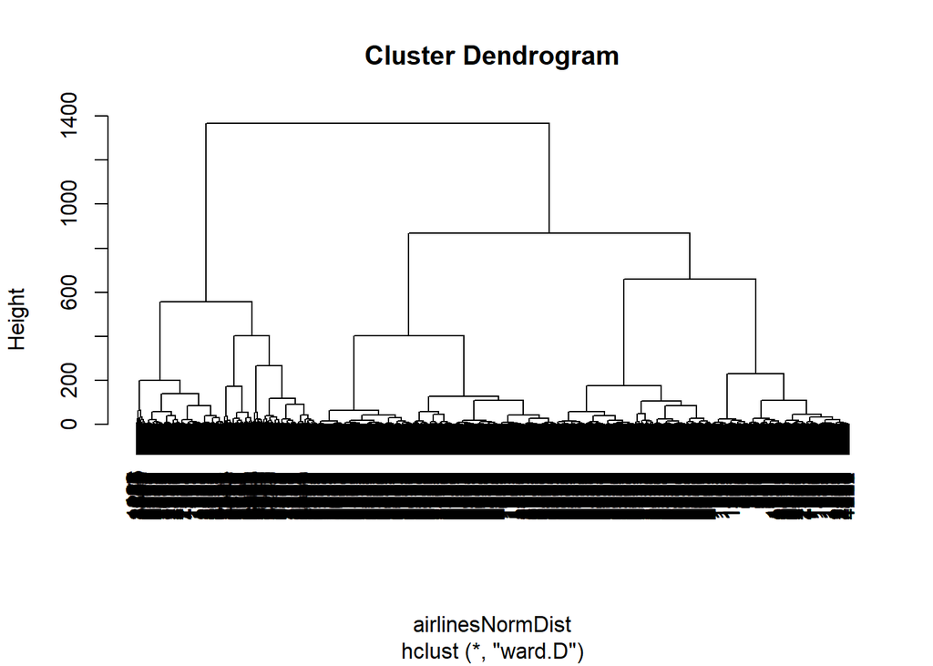

```r
# Hierarchical clustering algorithm
airlinesNormDist = dist(airlinesNorm, method="euclidean")
airlinesNormHierClust = hclust(airlinesNormDist, method="ward.D")
plot(airlinesNormHierClust)
```

#### According to the dendrogram, which of the following is NOT a good choice for the number of clusters?

If you run a horizontal line down the dendrogram, you can see that there is a long time that the line crosses 2 clusters, 3 clusters, or 7 clusters. However, it it hard to see the horizontal line cross 6 clusters. This means that 6 clusters is probably not a good choice.

#### Suppose that after looking at the dendrogram and discussing with the marketing department, the airline decides to proceed with 5 clusters. Divide the data points into 5 clusters by using the cutree function.

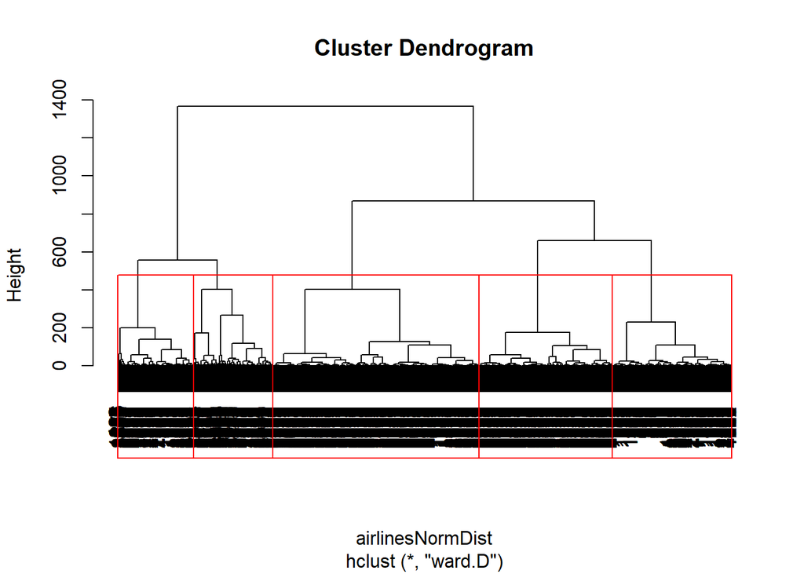

```r
# Plot a dendrogram and divide it into 5 clusters
plot(airlinesNormHierClust)
rect.hclust(airlinesNormHierClust, k = 5, border = "red")
```

```r
hierGroups = cutree(airlinesNormHierClust, k = 5)
# Subset the clusters into 5 different groups
HierCluster1 = subset(airlinesNorm, hierGroups == 1)
HierCluster2 = subset(airlinesNorm, hierGroups == 2)
HierCluster3 = subset(airlinesNorm, hierGroups == 3)
HierCluster4 = subset(airlinesNorm, hierGroups == 4)
HierCluster5 = subset(airlinesNorm, hierGroups == 5)
```

##### How many data points are in Cluster 1?

```r
# Outsput the number of rows
nrow(HierCluster1)
```

```
## [1] 776
```

##### Compare the average values in each of the variables

Now, use tapply to compare the average values in each of the variables for the 5 clusters (the centroids of the clusters). You may want to compute the average values of the unnormalized data so that it is easier to interpret. You can do this for the variable “Balance” with the following command:

```r
# Compares two different groups using a statistical measure
tapply(airlines$Balance, hierGroups, mean)
```

```
##         1         2         3         4         5
##  57866.90 110669.27 198191.57  52335.91  36255.91
```

```r
# Compares two different groups using a statistical measure
z = tapply(airlines$Balance, hierGroups, mean)
kable(z)
```

| x |
| --- |
| 57866.90 |
| 110669.27 |
| 198191.57 |
| 52335.91 |
| 36255.91 |

```r
z = tapply(airlines$QualMiles, hierGroups, mean)
kable(z)
```

| x |
| --- |
| 0.6443299 |
| 1065.9826590 |
| 30.3461538 |
| 4.8479263 |
| 2.5111773 |

```r
z = tapply(airlines$BonusMiles, hierGroups, mean)
kable(z)
```

| x |
| --- |
| 10360.124 |
| 22881.763 |
| 55795.860 |
| 20788.766 |
| 2264.788 |

```r
z = tapply(airlines$BonusTrans, hierGroups, mean)
kable(z)
```

| x |
| --- |
| 10.823454 |
| 18.229287 |
| 19.663968 |
| 17.087558 |
| 2.973174 |

```r
z = tapply(airlines$FlightMiles, hierGroups, mean)
kable(z)
```

| x |
| --- |
| 83.18428 |
| 2613.41811 |
| 327.67611 |
| 111.57373 |
| 119.32191 |

```r
z = tapply(airlines$FlightTrans, hierGroups, mean)
kable(z)
```

| x |
| --- |
| 0.3028351 |
| 7.4026975 |
| 1.0688259 |
| 0.3444700 |
| 0.4388972 |

```r
z = tapply(airlines$DaysSinceEnroll, hierGroups, mean)
kable(z)
```

| x |
| --- |
| 6235.365 |
| 4402.414 |
| 5615.709 |
| 2840.823 |
| 3060.081 |

###### Compared to the other clusters, Cluster 1 has the largest average values in which variables (if any)? Select all that apply.

Cluster 1 has the largest average values in DaysSinceEnroll.

###### How would you describe the customers in Cluster 1?

Customers in Cluster 1 are infrequent but loyal customers.

###### Compared to the other clusters, Cluster 2 has the largest average values in which variables (if any)? Select all that apply.

Cluster 2 has the largest average values in the variables QualMiles, FlightMiles and FlightTrans. This cluster also has relatively large values in BonusTrans and Balance.

###### How would you describe the customers in Cluster 2?

Cluster 2 contains customers with a large amount of miles, mostly accumulated through flight transactions.

###### Compared to the other clusters, Cluster 3 has the largest average values in which variables (if any)? Select all that apply.

Cluster 3 has the largest values in Balance, BonusMiles, and BonusTrans. While it also has relatively large values in other variables, these are the three for which it has the largest values.

###### How would you describe the customers in Cluster 3?

Cluster 3 mostly contains customers with a lot of miles, and who have earned the miles mostly through bonus transactions.

###### Compared to the other clusters, Cluster 4 has the largest average values in which variables (if any)? Select all that apply.

Cluster 4 does not have the largest values in any of the variables.

###### How would you describe the customers in Cluster 4?

Cluster 4 customers have the smallest value in DaysSinceEnroll, but they are already accumulating a reasonable number of miles.

###### Compared to the other clusters, Cluster 5 has the largest average values in which variables (if any)? Select all that apply.

Cluster 5 does not have the largest values in any of the variables.

###### How would you describe the customers in Cluster 5?

Cluster 5 customers have lower than average values in all variables.

### K-Means Clustering

Now run the k-means clustering algorithm on the normalized data, again creating 5 clusters. Set the seed to 88 right before running the clustering algorithm, and set the argument iter.max to 1000.

```r
# k-means algorithm
set.seed(88)
kmc = kmeans(airlinesNorm, centers=5, iter.max = 1000)
# Subset into 5 different cluster datasets
KmeansCluster1 = subset(airlinesNorm, kmc$cluster == 1)

KmeansCluster2 = subset(airlinesNorm, kmc$cluster == 2)

KmeansCluster3 = subset(airlinesNorm, kmc$cluster == 3)

KmeansCluster4 = subset(airlinesNorm, kmc$cluster == 4)

KmeansCluster5 = subset(airlinesNorm, kmc$cluster == 5)
```

#### How many clusters have more than 1,000 observations?

```r
# Calculates the number of rows in each cluster dataset
nrow(KmeansCluster1)
```

```
## [1] 408
```

```r
nrow(KmeansCluster2)
```

```
## [1] 141
```

```r
nrow(KmeansCluster3)
```

```
## [1] 993
```

```r
nrow(KmeansCluster4)
```

```
## [1] 1182
```

```r
nrow(KmeansCluster5)
```

```
## [1] 1275
```

There are two clusters with more than 1000 observations.

#### Do you expect Cluster 1 of the K-Means clustering output to necessarily be similar to Cluster 1 of the Hierarchical clustering output?

```r
# Compares two different groups using a statistical measure
z = tapply(airlines$Balance, kmc$cluster, mean)
kable(z)
```

| x |
| --- |
| 219161.40 |
| 174431.51 |
| 67977.44 |
| 60166.18 |
| 32706.67 |

```r
z = tapply(airlines$QualMiles, kmc$cluster, mean)
kable(z)
```

| x |
| --- |
| 539.57843 |
| 673.16312 |
| 34.99396 |
| 55.20812 |
| 126.46667 |

```r
z = tapply(airlines$BonusMiles, kmc$cluster, mean)
kable(z)
```

| x |
| --- |
| 62474.483 |
| 31985.085 |
| 24490.019 |
| 8709.712 |
| 3097.478 |

```r
z = tapply(airlines$BonusTrans, kmc$cluster, mean)
kable(z)
```

| x |
| --- |
| 21.524510 |
| 28.134752 |
| 18.429003 |
| 8.362098 |
| 4.284706 |

```r
z = tapply(airlines$FlightMiles, kmc$cluster, mean)
kable(z)
```

| x |
| --- |
| 623.8725 |
| 5859.2340 |
| 289.4713 |
| 203.2589 |
| 181.4698 |

```r
z = tapply(airlines$FlightTrans, kmc$cluster, mean)
kable(z)
```

| x |
| --- |
| 1.9215686 |
| 17.0000000 |
| 0.8851964 |
| 0.6294416 |
| 0.5403922 |

```r
z = tapply(airlines$DaysSinceEnroll, kmc$cluster, mean)
kable(z)
```

| x |
| --- |
| 5605.051 |
| 4684.901 |
| 3416.783 |
| 6109.540 |
| 2281.055 |

The clusters are not displayed in a meaningful order, so while there may be a cluster produced by the k-means algorithm that is similar to Cluster 1 produced by the Hierarchical method, it will not necessarily be shown first.